# Human Activity Recognition Model

Stephan Rossbauer

Friday, June 19, 2015

# Executive Summary

Using devices such as Jawbone Up, Nike FuelBand, and Fitbit it is now possible to collect a large amount of data about personal activity relatively inexpensively. These type of devices are part of the quantified self movement - a group of enthusiasts who take measurements about themselves regularly to improve their health, to find patterns in their behavior, or because they are tech geeks. One thing that people regularly do is quantify how much of a particular activity they do, but they rarely quantify how well they do it. In this project, our goal is be to use data from accelerometers on the belt, forearm, arm, and dumbell of 6 participants. They were asked to perform barbell lifts correctly and incorrectly in 5 different ways. More information is available from the website here:

http://groupware.les.inf.puc-rio.br/har

(see the section on the Weight Lifting Exercise Dataset).

## Libraries

```r
library(caret)
library(corrplot)
library(doParallel)
```

## Data loading and preprocessing

```r
# create data directory if needed
if (!file.exists("data")) {dir.create("data")}

# file URL and destination file
fileUrl1 <- "https://d396qusza40orc.cloudfront.net/predmachlearn/pml-training.csv"
destfile1 <- "./data/pml-training.csv"
fileUrl2 <- "https://d396qusza40orc.cloudfront.net/predmachlearn/pml-testing.csv"
destfile2 <- "./data/pml-testing.csv"

# download the files
download.file(fileUrl1, destfile = destfile1)
download.file(fileUrl2, destfile = destfile2)
```

Loading and cleaning the data, removing all the columns with NAs

```r
## read data
setwd("~/GitHub/datasciencecoursera/machine learning")
d <- read.csv("data\\pml-training.csv", na.strings = c("", "#DIV/0!","NA"))
col_nas <- colSums(is.na(d))
td <- d[, col_nas<1]
# get rid of bookkeeping columns
td <- td[,-(1:7)]
rm("d")
```

This leaves us with 52 variables to predict the outcome classe

# Prediction Model

Create a training and a test partition for cross validation

```r
set.seed(1984)
trainPartition <- createDataPartition(y=td$classe, p=0.5, list=FALSE )
train1 <- td[trainPartition,]
test1 <- td[-trainPartition,]
```

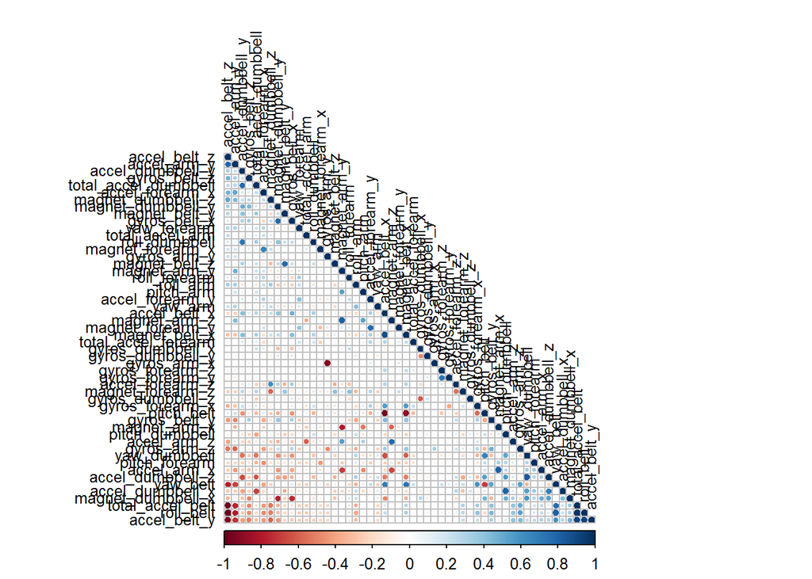

```r
correlMatrix <- cor(train1[, -length(train1)])
corrplot(correlMatrix, order = "FPC", method = "circle", type = "lower", tl.cex = 0.8,  tl.col = rgb(0, 0, 0))
```

The figure indicates the correlation between variables, the darker the color is the stronger the correlation. There are sufficient un correlated variable to move forward with this data set to use random forests

```r
# enable multi-core processing

cl <- makeCluster(detectCores())
registerDoParallel(cl)

# random forest fit, if object already exists, skip and load object
fitControl<-trainControl(method="cv", 3)
if(file.exists("rfModel.Rda")){
  load("rfModel.Rda")} else {
rffit<-train(classe ~ .,data=train1,method="rf",trControl=fitControl)
}

stopCluster(cl)

rffit
```

```
## Random Forest
##
## 9812 samples
##   52 predictor
##    5 classes: 'A', 'B', 'C', 'D', 'E'
##
## No pre-processing
## Resampling: Cross-Validated (3 fold)
##
## Summary of sample sizes: 6542, 6541, 6541
##
## Resampling results across tuning parameters:
##
##   mtry  Accuracy   Kappa      Accuracy SD  Kappa SD
##    2    0.9812471  0.9762705  0.003357603  0.004249755
##   27    0.9839993  0.9797586  0.003697403  0.004675519
##   52    0.9768650  0.9707360  0.004173782  0.005274611
##
## Accuracy was used to select the optimal model using  the largest value.
## The final value used for the model was mtry = 27.
```

The model produces a very high accuracy.

## Cross-validation

```r
rfpredict <- predict(rffit, newdata = test1)
confusionMatrix(data = rfpredict, test1$classe)
```

```
## Confusion Matrix and Statistics
##
##           Reference
## Prediction    A    B    C    D    E
##          A 2780   24    0    0    0
##          B    6 1847   21    3    1
##          C    3   26 1683   22    6
##          D    0    1    7 1581    8
##          E    1    0    0    2 1788
##
## Overall Statistics
##
##                Accuracy : 0.9866
##                  95% CI : (0.9842, 0.9888)
##     No Information Rate : 0.2844
##     P-Value [Acc > NIR] : < 2.2e-16
##
##                   Kappa : 0.9831
##  Mcnemar's Test P-Value : NA
##
## Statistics by Class:
##
##                      Class: A Class: B Class: C Class: D Class: E
## Sensitivity            0.9964   0.9731   0.9836   0.9832   0.9917
## Specificity            0.9966   0.9961   0.9930   0.9980   0.9996
## Pos Pred Value         0.9914   0.9835   0.9672   0.9900   0.9983
## Neg Pred Value         0.9986   0.9936   0.9965   0.9967   0.9981
## Prevalence             0.2844   0.1935   0.1744   0.1639   0.1838
## Detection Rate         0.2834   0.1883   0.1716   0.1612   0.1823
## Detection Prevalence   0.2858   0.1914   0.1774   0.1628   0.1826
## Balanced Accuracy      0.9965   0.9846   0.9883   0.9906   0.9957
```

# Predictions

```r
### testing

testingRaw <- read.csv("data\\pml-testing.csv", na.strings = c("", "#DIV/0!","NA"))

rfpredict <- predict(rffit, newdata = testingRaw)

rfpredict
```

```
##  [1] B A B A A E D B A A B C B A E E A B B B
## Levels: A B C D E
```

Cross checking with the acutal values tells us that we were able to correctly predict all 20 new cases.